# The relationship between task measures and the two symptom factors (regression analysis)

In this script, the relationship between the task measures derived from the Facial Expression Recognition Task and symptom factors are analysed. The task measures are analysed individually using multiple linear regression. Scores for the two factors Anxiety-Depression and Anhedonia-Apathy are included as predictors of interest. To control for age, gender and education, these variables are added as additional regressors. To control for task performance, a general measure of task performance is included as additional regressor.

The task measures include: - Unbiased Hit Rate for each emotion (a measure for how often each emotion was correctly identified) - Reaction times - Positive bias for Unbiased Hit Rate and reaction times, i.e. the extent to which participants were more accurate or faster for positive compared to negative emotions

```r
# Settings for Stan/BRMS
niter=8000
nchains=4
adaptdeltas=0.9
```

### Regression analyses for Unbiased Hit Rate (UHR)

```r
# Mean unbiased hit rate across emotions (will be used as control regressor)

UHR_mean_across_emotions <-brm(formula = FERT_UHR_mean_across_emotions ~ AnxietyDepression + AnhedoniaApathy +
                 Age + Gender + mo(Education), data=all,family='gaussian',iter=niter,chains=nchains,cores=nchains,
                 control=list(adapt_delta=adaptdeltas))
#summary(UHR_mean_across_emotions)

# Unbiased hit rate ###########################################################################################

# "raw" hit rate, controlled for mean hit rate ("FERT_UHR_mean_across_emotions")
UHR_happy_c <-brm(formula = FERT_UHR_happy ~ AnxietyDepression + AnhedoniaApathy +
                Age + Gender + mo(Education) + FERT_UHR_mean_across_emotions,
                data=all,family='gaussian',iter=niter,chains=nchains,cores=nchains,
                control=list(adapt_delta=adaptdeltas))
#summary(UHR_happy_c)

UHR_surprise_c <-brm(formula = FERT_UHR_surprise ~ AnxietyDepression + AnhedoniaApathy +
                Age + Gender + mo(Education) + FERT_UHR_mean_across_emotions,
                data=all,family='gaussian',iter=niter,chains=nchains,cores=nchains,
                control=list(adapt_delta=adaptdeltas))
#summary(UHR_surprise_c)

UHR_sad_c <-brm(formula = FERT_UHR_sad ~ AnxietyDepression + AnhedoniaApathy +
                Age + Gender + mo(Education) + FERT_UHR_mean_across_emotions,
                data=all,family='gaussian',iter=niter,chains=nchains,cores=nchains,
                control=list(adapt_delta=adaptdeltas))
#summary(UHR_sad_c)

UHR_fear_c <-brm(formula = FERT_UHR_fear ~ AnxietyDepression + AnhedoniaApathy +
                Age + Gender + mo(Education) + FERT_UHR_mean_across_emotions,
                data=all,family='gaussian',iter=niter,chains=nchains,cores=nchains,
                control=list(adapt_delta=adaptdeltas))
#summary(UHR_fear_c)

UHR_anger_c <-brm(formula = FERT_UHR_anger ~ AnxietyDepression + AnhedoniaApathy +
                Age + Gender + mo(Education) + FERT_UHR_mean_across_emotions,
                data=all,family='gaussian',iter=niter,chains=nchains,cores=nchains,
                control=list(adapt_delta=adaptdeltas))
#summary(UHR_anger_c)

UHR_disgust_c <-brm(formula = FERT_UHR_disgust ~ AnxietyDepression + AnhedoniaApathy +
                Age + Gender + mo(Education) + FERT_UHR_mean_across_emotions,
                data=all,family='gaussian',iter=niter,chains=nchains,cores=nchains,
                control=list(adapt_delta=adaptdeltas))
#summary(UHR_disgust_c)



# Unbiased hit rate positive bias

Unbiased_hit_rate_positive_bias_log <-brm(formula = FERT_Unbiased_hit_rate_positive_bias_log ~ AnxietyDepression + AnhedoniaApathy+
                Age + Gender + mo(Education) + FERT_UHR_mean_across_emotions, data=all,family='gaussian',iter=niter,
                chains=nchains, cores=nchains, control=list(adapt_delta=adaptdeltas))
```

### Regression analyses for reaction times (RT)

```r
# Reaction times ############################################################################################################

RT_mean_across_emotions <- brm(formula = FERT_RT_mean_across_emotions ~ AnxietyDepression + AnhedoniaApathy +
                Age + Gender + mo(Education), data=all,family='gaussian',iter=niter,chains=nchains,cores=nchains,
                control=list(adapt_delta=adaptdeltas))
#summary(RT_mean_across_emotions)

# "raw"
RT_happy <- brm(formula = FERT_RT_happy ~ AnxietyDepression + AnhedoniaApathy +
                 Age + Gender + mo(Education) + FERT_RT_mean_across_emotions, data=all,family='gaussian',iter=niter,
                 chains=nchains, cores=nchains, control=list(adapt_delta=adaptdeltas))
#summary(RT_happy)

RT_surprise <- brm(formula = FERT_RT_surprise ~ AnxietyDepression + AnhedoniaApathy +
                 Age + Gender + mo(Education) + FERT_RT_mean_across_emotions, data=all,family='gaussian',iter=niter,
                 chains=nchains, cores=nchains, control=list(adapt_delta=adaptdeltas))
#summary(RT_surprise)

RT_sad <- brm(formula = FERT_RT_sad ~ AnxietyDepression + AnhedoniaApathy +
                 Age + Gender + mo(Education) + FERT_RT_mean_across_emotions, data=all,family='gaussian',iter=niter,
                 chains=nchains, cores=nchains, control=list(adapt_delta=adaptdeltas))
#summary(RT_sad)

RT_fear <- brm(formula = FERT_RT_fear~ AnxietyDepression + AnhedoniaApathy +
                 Age + Gender + mo(Education) + FERT_RT_mean_across_emotions, data=all,family='gaussian',iter=niter,
                 chains=nchains, cores=nchains, control=list(adapt_delta=adaptdeltas))
#summary(RT_fear)

RT_anger <- brm(formula = FERT_RT_anger~ AnxietyDepression + AnhedoniaApathy +
                 Age + Gender + mo(Education) + FERT_RT_mean_across_emotions, data=all,family='gaussian',iter=niter,
                 chains=nchains, cores=nchains, control=list(adapt_delta=adaptdeltas))
#summary(RT_anger)

RT_disgust <- brm(formula = FERT_RT_disgust~ AnxietyDepression + AnhedoniaApathy +
                 Age + Gender + mo(Education) + FERT_RT_mean_across_emotions, data=all,family='gaussian',iter=niter,
                 chains=nchains, cores=nchains, control=list(adapt_delta=adaptdeltas))
#summary(RT_disgust)

# RT positive bias

Positive_bias_RT_log <- brm(formula = FERT_Positive_bias_RT_log~ AnxietyDepression + AnhedoniaApathy +
                 Age + Gender + mo(Education) + FERT_RT_mean_across_emotions, data=all,family='gaussian',iter=niter,
                 chains=nchains, cores=nchains, control=list(adapt_delta=adaptdeltas))
#summary(Positive_bias_RT_log)
```

### Extract regression coefficients

```r
# Unbiased Hit Rate (UHR)

UHR_mean_across_emotions_est <- summary(UHR_mean_across_emotions)
UHR_mean_across_emotions_est <- UHR_mean_across_emotions_est$fixed
UHR_mean_across_emotions_est$Parameter <- "UHR_mean_across_emotions"

UHR_happy_est <- summary(UHR_happy_c)
UHR_happy_est <- UHR_happy_est$fixed
UHR_happy_est$Parameter <- "UHR_happy"

UHR_surprise_est <- summary(UHR_surprise_c)
UHR_surprise_est <- UHR_surprise_est$fixed
UHR_surprise_est$Parameter <- "UHR_surprise"

UHR_sad_est <- summary(UHR_sad_c)
UHR_sad_est <- UHR_sad_est$fixed
UHR_sad_est$Parameter <- "UHR_sad"

UHR_fear_est <- summary(UHR_fear_c)
UHR_fear_est <- UHR_fear_est$fixed
UHR_fear_est$Parameter <- "UHR_fear"

UHR_anger_est <- summary(UHR_anger_c)
UHR_anger_est <- UHR_anger_est$fixed
UHR_anger_est$Parameter <- "UHR_anger"

UHR_disgust_est <- summary(UHR_disgust_c)
UHR_disgust_est <- UHR_disgust_est$fixed
UHR_disgust_est$Parameter <- "UHR_disgust"

Unbiased_hit_rate_positive_bias_log_est <- summary(Unbiased_hit_rate_positive_bias_log)
Unbiased_hit_rate_positive_bias_log_est <- Unbiased_hit_rate_positive_bias_log_est$fixed
Unbiased_hit_rate_positive_bias_log_est$Parameter <- "Unbiased_hit_rate_positive_bias_log"

# RT

RT_mean_across_emotions_est <- summary(RT_mean_across_emotions)
RT_mean_across_emotions_est <- RT_mean_across_emotions_est$fixed
RT_mean_across_emotions_est$Parameter <- "RT_mean_across_emotions"

RT_happy_est <- summary(RT_happy)
RT_happy_est <- RT_happy_est$fixed
RT_happy_est$Parameter <- "RT_happy"

RT_surprise_est <- summary(RT_surprise)
RT_surprise_est <- RT_surprise_est$fixed
RT_surprise_est$Parameter <- "RT_surprise"

RT_sad_est <- summary(RT_sad)
RT_sad_est <- RT_sad_est$fixed
RT_sad_est$Parameter <- "RT_sad"

RT_fear_est <- summary(RT_fear)
RT_fear_est <- RT_fear_est$fixed
RT_fear_est$Parameter <- "RT_fear"

RT_anger_est <- summary(RT_anger)
RT_anger_est <- RT_anger_est$fixed
RT_anger_est$Parameter <- "RT_anger"

RT_disgust_est <- summary(RT_disgust)
RT_disgust_est <- RT_disgust_est$fixed
RT_disgust_est$Parameter <- "RT_disgust"

Positive_bias_RT_log_est <- summary(Positive_bias_RT_log)
Positive_bias_RT_log_est <- Positive_bias_RT_log_est$fixed
Positive_bias_RT_log_est$Parameter <- "Positive_bias_RT_log"
```

### Plot regression weights for Anxiety-Depression

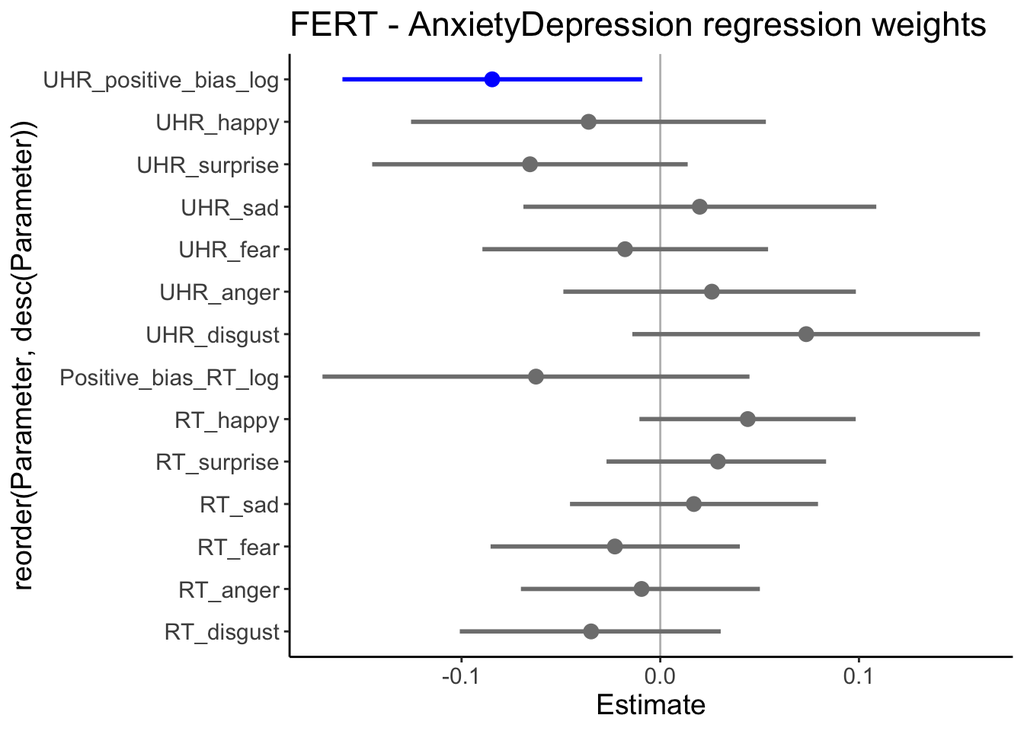

```r
FERT_AnxietyDepression <- rbind(UHR_happy_est[2,], UHR_surprise_est[2,], UHR_sad_est[2,], UHR_fear_est[2,], UHR_anger_est[2,], UHR_disgust_est[2,],  Unbiased_hit_rate_positive_bias_log_est[2,], RT_happy_est[2,], RT_surprise_est[2,], RT_sad_est[2,], RT_fear_est[2,], RT_anger_est[2,], RT_disgust_est[2,], Positive_bias_RT_log_est[2,])

FERT_AnxietyDepression$Parameter[FERT_AnxietyDepression$Parameter=="Unbiased_hit_rate_positive_bias_log"] <- "UHR_positive_bias_log"

FERT_AnxietyDepression$Parameter <- factor(FERT_AnxietyDepression$Parameter, levels = c("UHR_positive_bias_log","UHR_happy", "UHR_surprise",
                                                                                        "UHR_sad","UHR_fear","UHR_anger", "UHR_disgust", "Positive_bias_RT_log",
                                                                                        "RT_happy","RT_surprise", "RT_sad", "RT_fear","RT_anger", "RT_disgust"))


FERT_AnxietyDepression$ParameterFERT_AnxietyDepression$sig <- F
FERT_AnxietyDepression$sig[(FERT_AnxietyDepression$`l-95% CI` > 0  & FERT_AnxietyDepression$`u-95% CI` > 0 )| (FERT_AnxietyDepression$`l-95% CI` < 0 & FERT_AnxietyDepression$`u-95% CI` < 0)] <- T
FERT_AnxietyDepression$Task <- "FERT"

ggplot(data=FERT_AnxietyDepression)+
  geom_hline(yintercept = 0, colour = "grey")+
  geom_errorbar(aes(reorder(Parameter, desc(Parameter)), ymin = `l-95% CI`, ymax = `u-95% CI`, colour = sig), size=1, width=0)+
  geom_point(aes(Parameter, Estimate, colour = sig), size=3)+
  theme(text = element_text(size = 14))+
  scale_colour_manual("legend",values=c("TRUE"="blue","FALSE"="grey50"))+
  theme(legend.position="none",panel.grid.major = element_blank(), panel.grid.minor = element_blank(),
        panel.background = element_blank(), axis.line = element_line(colour = "black"))+
  coord_flip()+
  ggtitle("FERT - AnxietyDepression regression weights")
```

Anxiety-Depression score significantly predicted a positive bias in the Unbaised Hit Rate. Individuals with higher Anxiety-Depression scores showed a less pronounced bias towards positive emotions.

### Plot regression weights for Anhedonia-Apathy

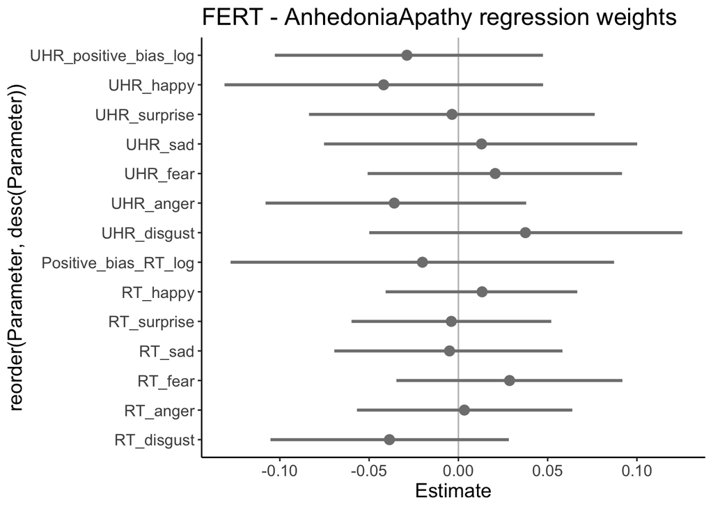

```r
# Plot regression weights for Anhedonia-Apathy

FERT_AnhedoniaApathy <- rbind(UHR_happy_est[3,], UHR_surprise_est[3,], UHR_sad_est[3,], UHR_fear_est[3,], UHR_anger_est[3,], UHR_disgust_est[3,],  Unbiased_hit_rate_positive_bias_log_est[3,], RT_happy_est[3,], RT_surprise_est[3,], RT_sad_est[3,], RT_fear_est[3,], RT_anger_est[3,], RT_disgust_est[3,], Positive_bias_RT_log_est[3,])

FERT_AnhedoniaApathy$Parameter[FERT_AnhedoniaApathy$Parameter=="Unbiased_hit_rate_positive_bias_log"] <- "UHR_positive_bias_log"

FERT_AnhedoniaApathy$Parameter <- factor(FERT_AnhedoniaApathy$Parameter, levels = c("UHR_positive_bias_log","UHR_happy", "UHR_surprise",
                                                                                        "UHR_sad","UHR_fear","UHR_anger", "UHR_disgust", "Positive_bias_RT_log",
                                                                                        "RT_happy","RT_surprise", "RT_sad", "RT_fear","RT_anger", "RT_disgust"))


FERT_AnhedoniaApathy$sig <- F
FERT_AnhedoniaApathy$sig[(FERT_AnhedoniaApathy$`l-95% CI` > 0  & FERT_AnhedoniaApathy$`u-95% CI` > 0 )| (FERT_AnhedoniaApathy$`l-95% CI` < 0 & FERT_AnhedoniaApathy$`u-95% CI` < 0)] <- T
FERT_AnhedoniaApathy$Task <- "FERT"

ggplot(data=FERT_AnhedoniaApathy)+
  geom_hline(yintercept = 0, colour = "grey")+
  geom_errorbar(aes(reorder(Parameter, desc(Parameter)), ymin = `l-95% CI`, ymax = `u-95% CI`, colour = sig), size=1, width=0)+
  geom_point(aes(Parameter, Estimate, colour = sig), size=3)+
  theme(text = element_text(size = 14))+
  scale_colour_manual("legend",values=c("TRUE"="blue","FALSE"="grey50"))+
  theme(legend.position="none",panel.grid.major = element_blank(), panel.grid.minor = element_blank(),
        panel.background = element_blank(), axis.line = element_line(colour = "black"))+
  coord_flip()+
  ggtitle("FERT - AnhedoniaApathy regression weights")
```

Anhedonia-Apathy scores did not significantly predict any task measure. This indicates that the relationship with the positive bias in the Unbiased Hit Rate was specific to Anxiety-Depression symptoms.